# EDA

Orphelia

March 16 2020

## I- About participants

- 407 participants from 41 countries residing in 30 countries
- 3 main countries of origin: 29% Ivory Coast, 19% Nigeria, 18% India, 5% Canada
- 3 main countries of residence: 24% USA, 20% Canada, 12% Nigeria
- Below is an interactive map of participants’ countries of origin and residence:
- **Interactivity**: click on circles or icons to display country name, count of participants from and residing in the country
- **Circle Color and Size**: driven by count of participants from a given country :
  - less than 10 : green
  - 10 - 30 : yellow
  - 30 - 50: orange
  - greater than 50 : red

[interactive chart not shown]

### Distribution of Participants’ blood types vs. Distribution in main countries

[Source](https://en.wikipedia.org/wiki/Blood_type_distribution_by_country)

| Blood Group | Participants (%) | Ivory Coast (%) | Nigeria (%) | India (%) | Canada (%) | Kenya (%) | Ghana (%) | USA (%) |
| --- | --- | --- | --- | --- | --- | --- | --- | --- |
| A- | 2.2 | 1 | 0.7 | 0.6 | 6 | 1 | 1.3 | 6.3 |
| A+ | 20.9 | 22.5 | 22.4 | 20.8 | 36 | 25.2 | 17.6 | 35.7 |
| AB- | 1 | 0.2 | 0.1 | 0.5 | 0.5 | 0 | 0.2 | 0.6 |
| AB+ | 7.4 | 4.3 | 2.6 | 8.9 | 2.5 | 4.2 | 2.8 | 3.4 |
| B- | 2 | 1 | 0.6 | 1.8 | 1.4 | 0.9 | 1.3 | 1.5 |
| B+ | 20.4 | 22.5 | 20.7 | 38.1 | 7.6 | 21.3 | 18.3 | 8.5 |
| O- | 5.2 | 2 | 1.6 | 1.4 | 7 | 1.8 | 4.5 | 6.6 |
| O+ | 41 | 46.5 | 51.3 | 27.9 | 39 | 45.6 | 53.8 | 37.4 |

- The distribution of blood types in our sample is well aligned with that of the most represented countries. The major groups are:
  - 41% O+
  - 21% A+
  - 20% B+

### Gender, Relationship Status, Age

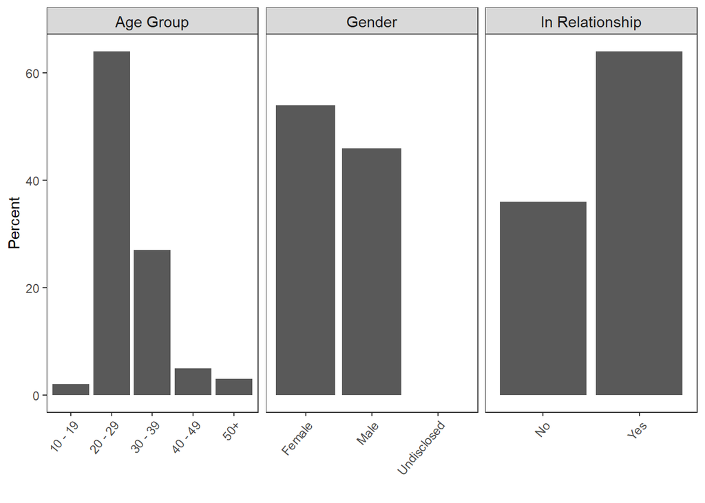

- 64% of participants are between 20 and 29 years old. The second biggest age group is 30 to 39 (27%) followed by 40 to 49 (5%)
- 54% of participants are Female , 46% Male
- 64% of participants are in a relationship

### Relationship between the blood group of participants and their partners’

| Participants' Blood Type | Their Partners' Blood Type | Count | Percent |
| --- | --- | --- | --- |
| A- | A+ | 1 | 11 |
| A- | N/A | 4 | 44 |
| A- | O- | 1 | 11 |
| A- | O+ | 3 | 33 |
| A+ | A- | 1 | 1 |
| A+ | A+ | 15 | 18 |
| A+ | AB+ | 5 | 6 |
| A+ | B- | 1 | 1 |
| A+ | B+ | 5 | 6 |
| A+ | I don't know | 29 | 34 |

[output cut: 36 more lines]

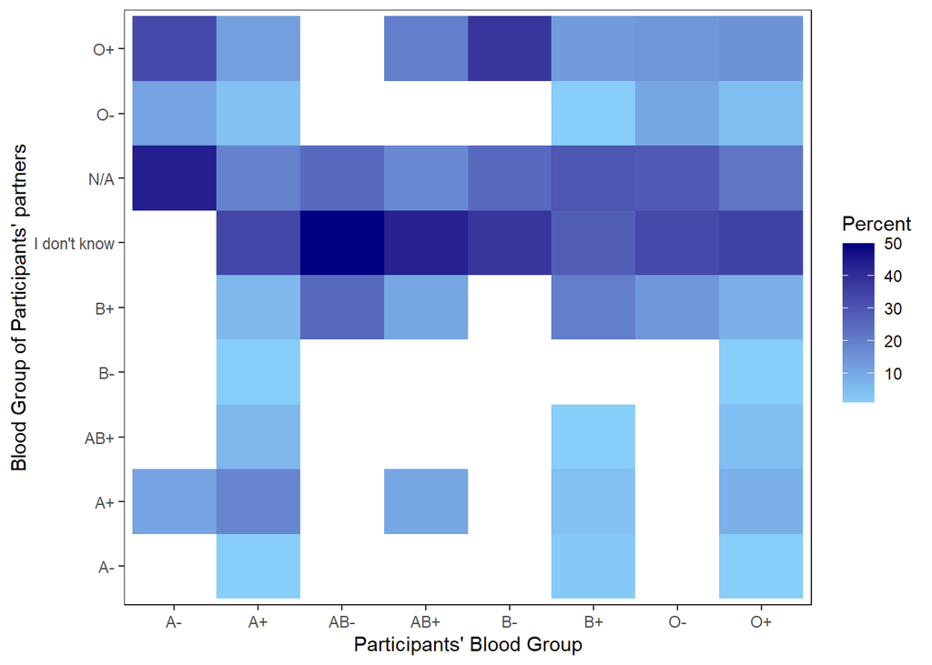

- This plot is called a heatmap. It is a chart that uses colors to represent values the way a bar plot uses height and width
- The chart shows the different combinations of participants’ blood type and their partners’. The color spectrum varies from light sky blue (low percentage) to navy blue (high percentage)
- Most participants who indicated being in a relationship do not know the blood group of their partners as shown by the darker colors in the “I don’t know” row
- A+ , B+ and O+ participants stand out. Those who are in a relationship and know their partners’ blood type are more likely to date someone with the same blood group
  - A+: 18% A+, 12% O+
  - B+: 20% B+, 13% O+
  - O+: 15% O+, 8% B+

## II- Relationship between Blood Group and Personality

### Excluding Rh factor: +/-

#### Group 1 :

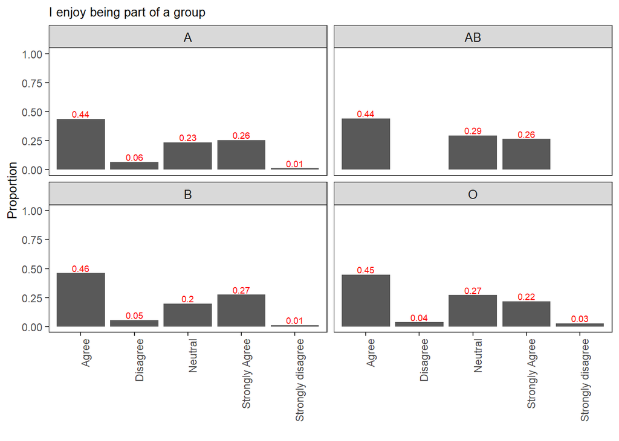

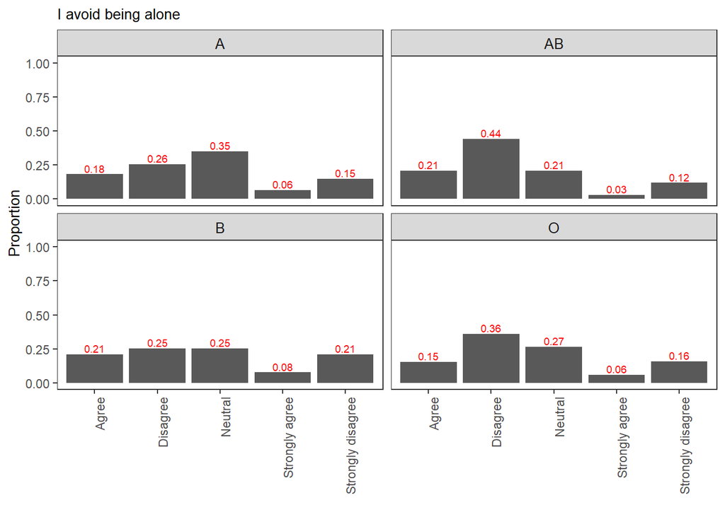

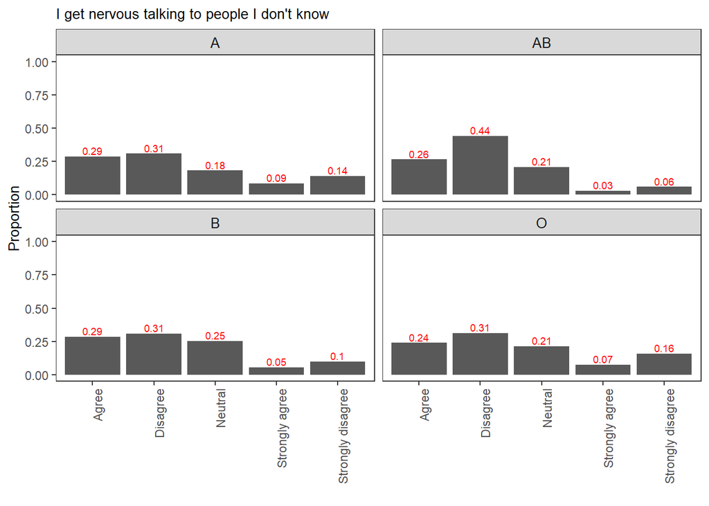

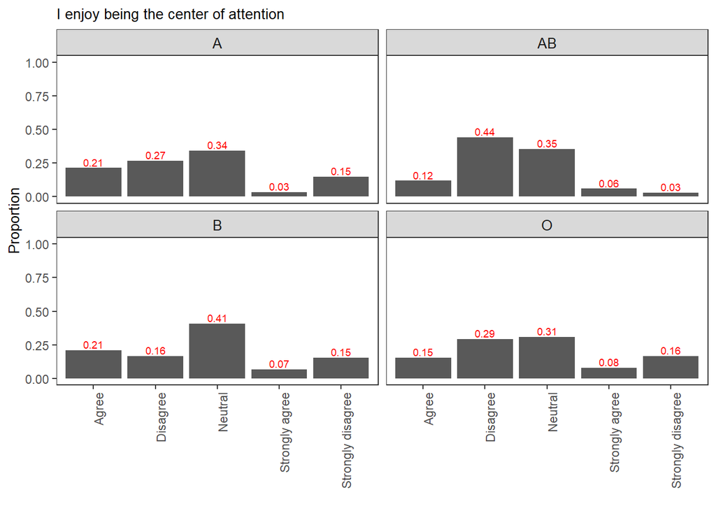

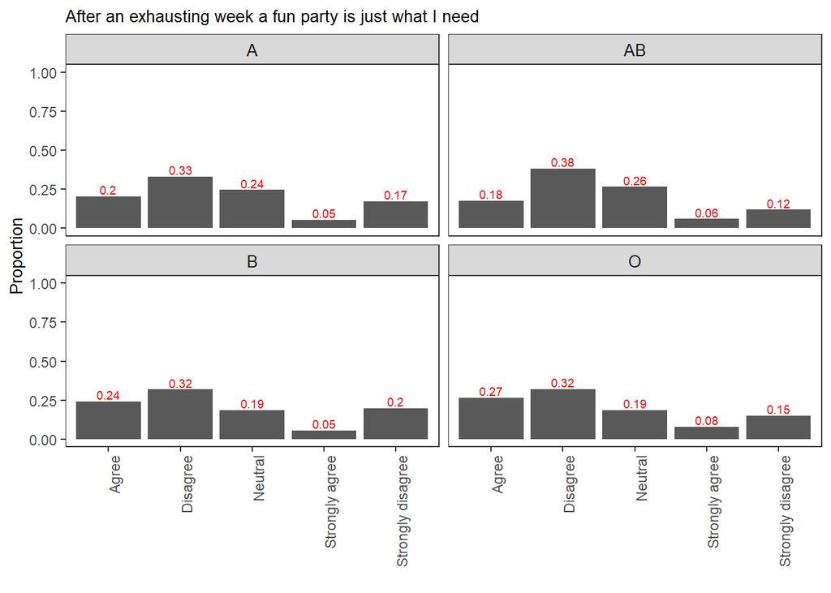

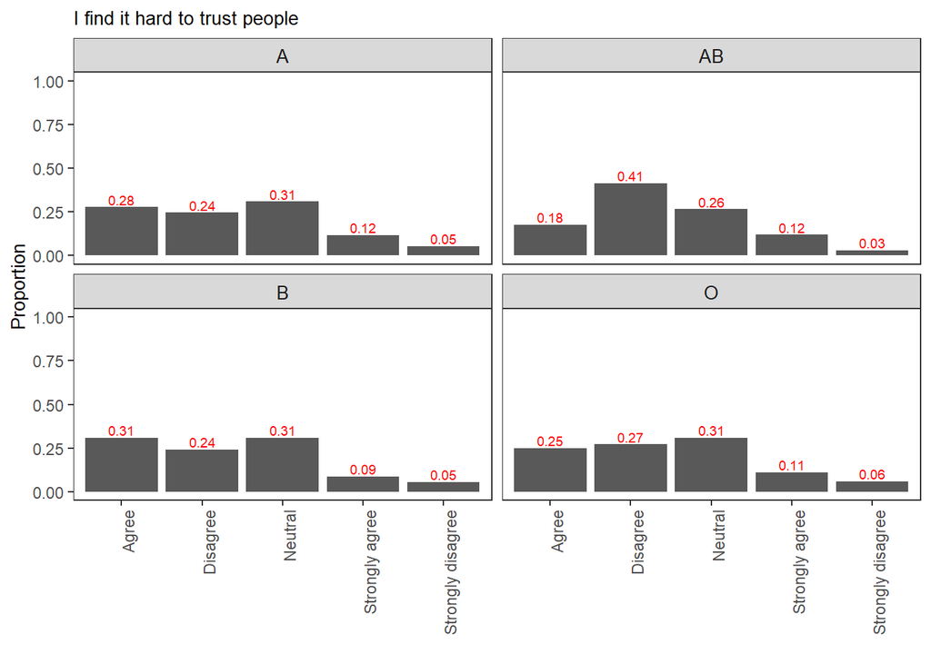

#### Group 2 :

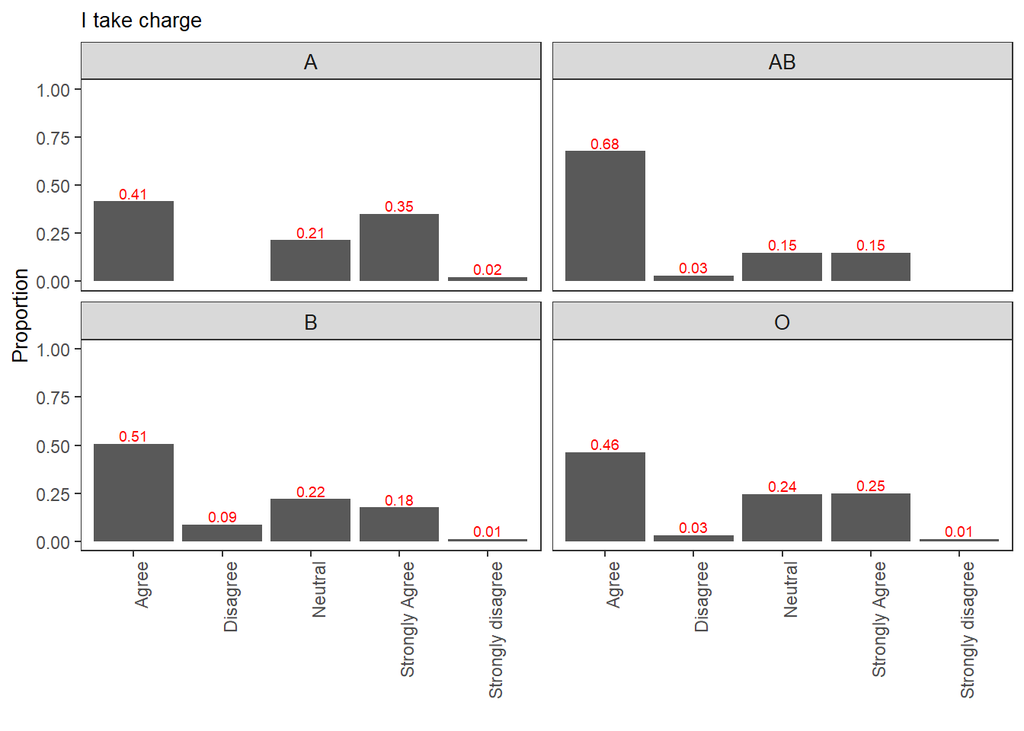

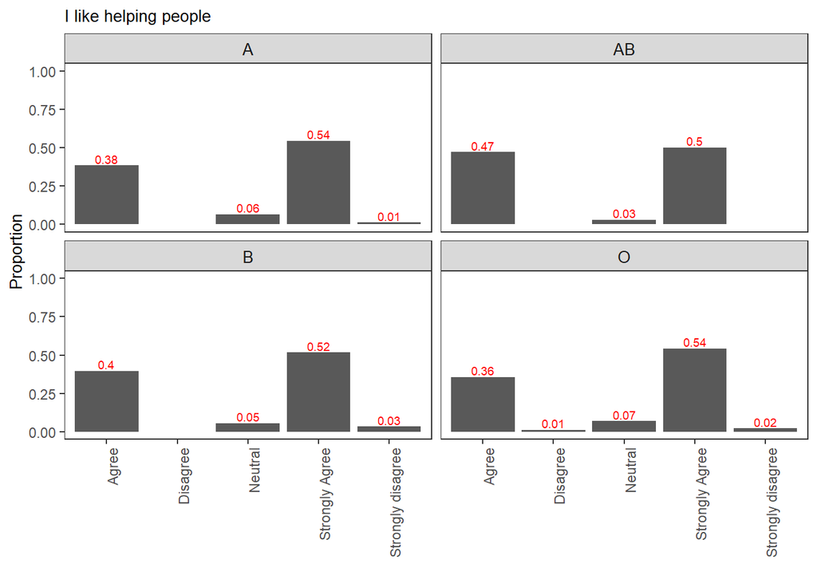

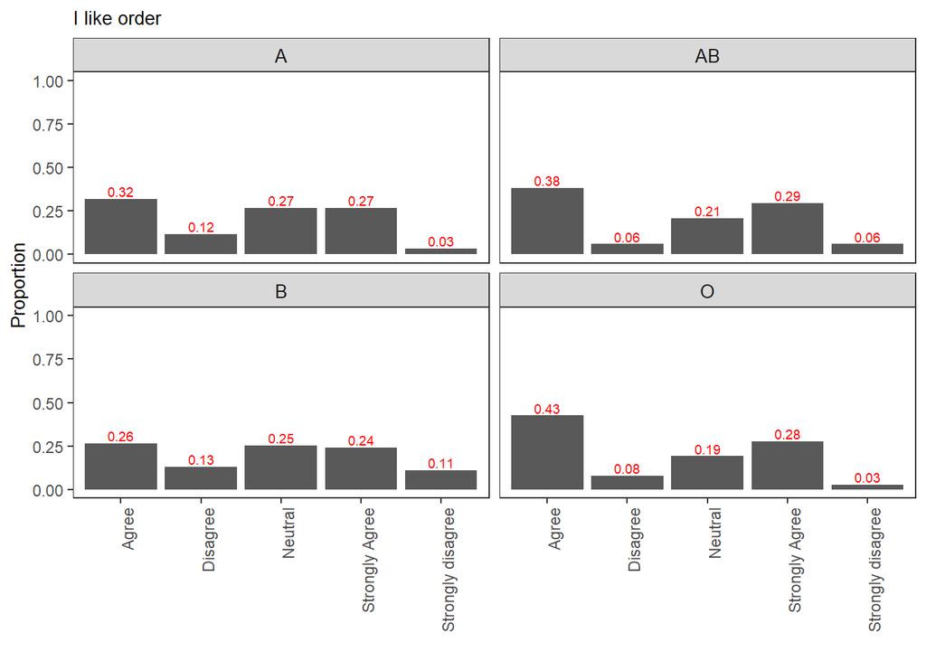

#### Group 3:

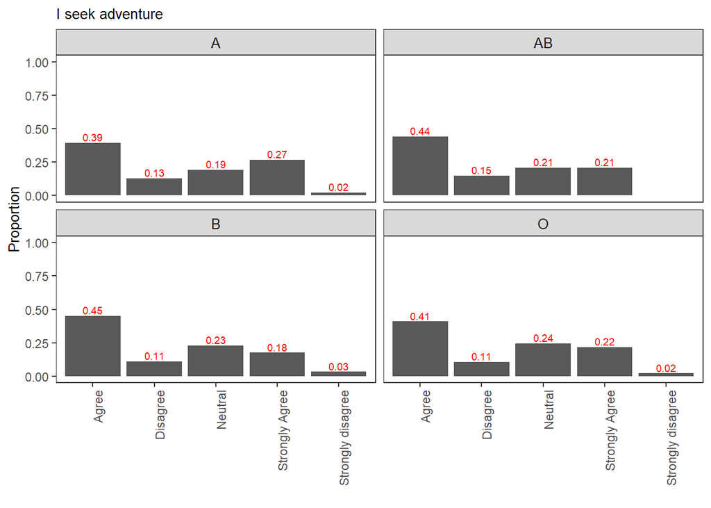

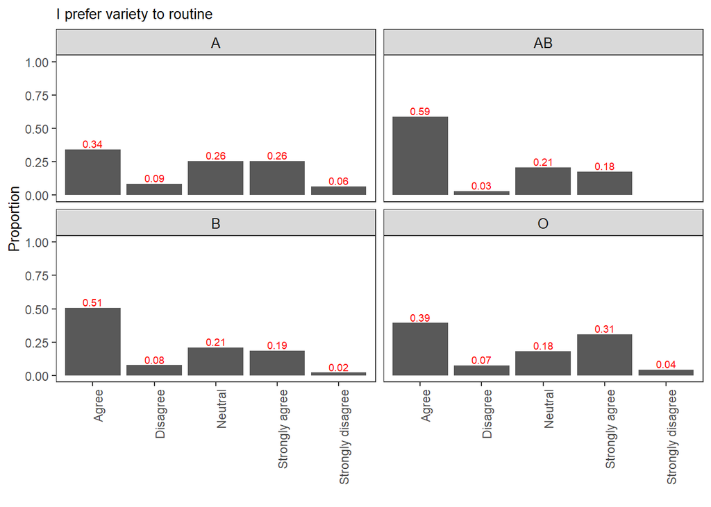

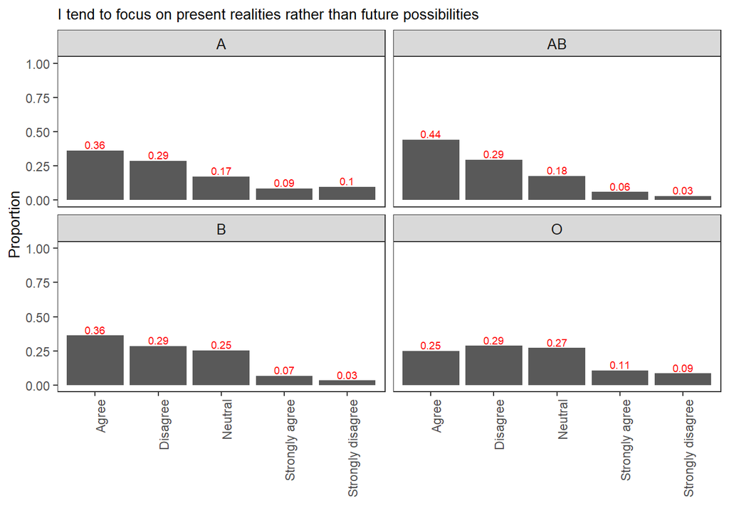

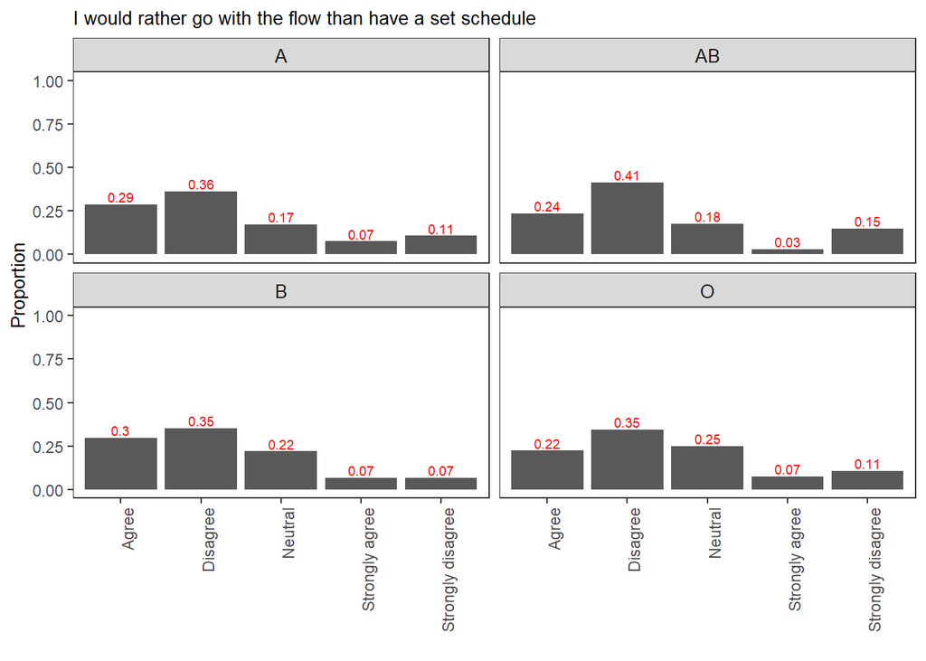

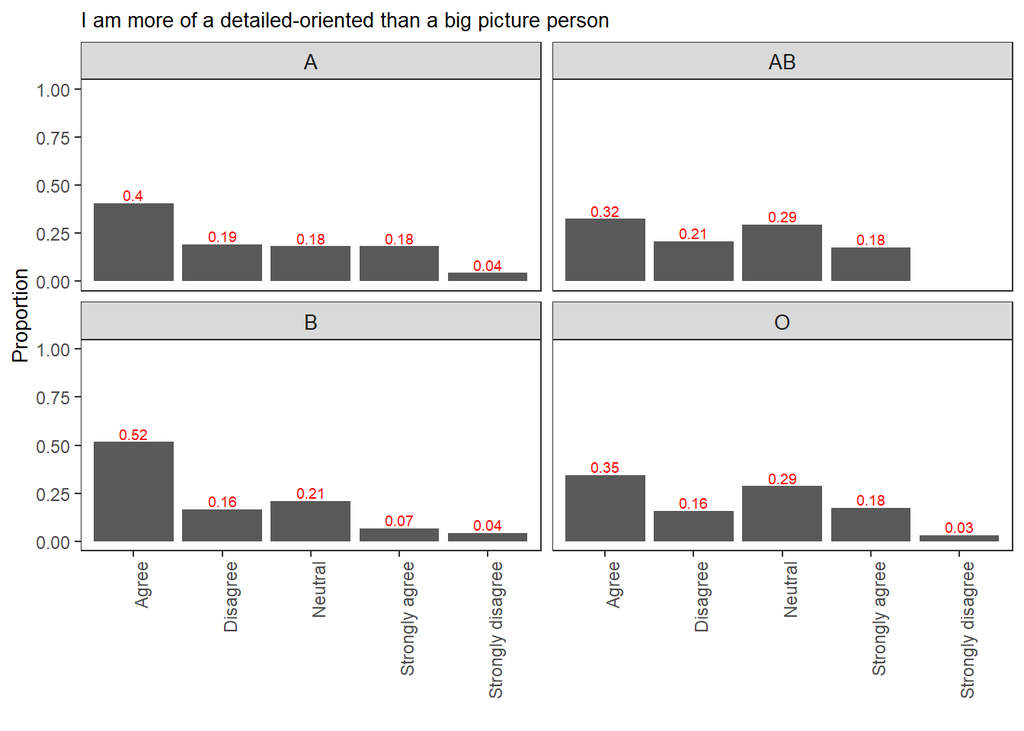

#### Group 4:

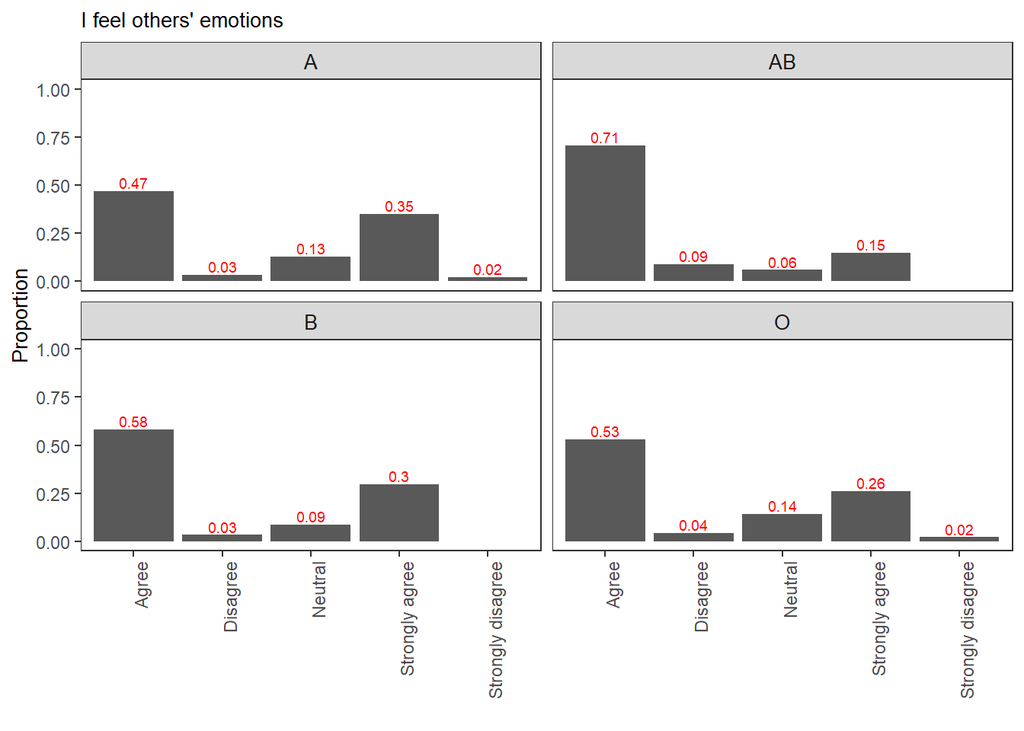

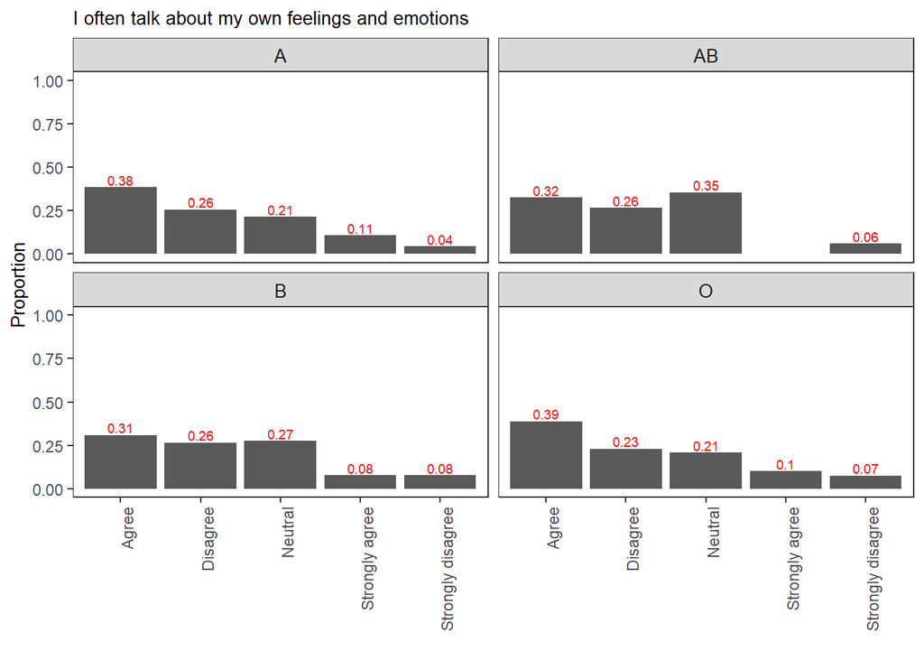

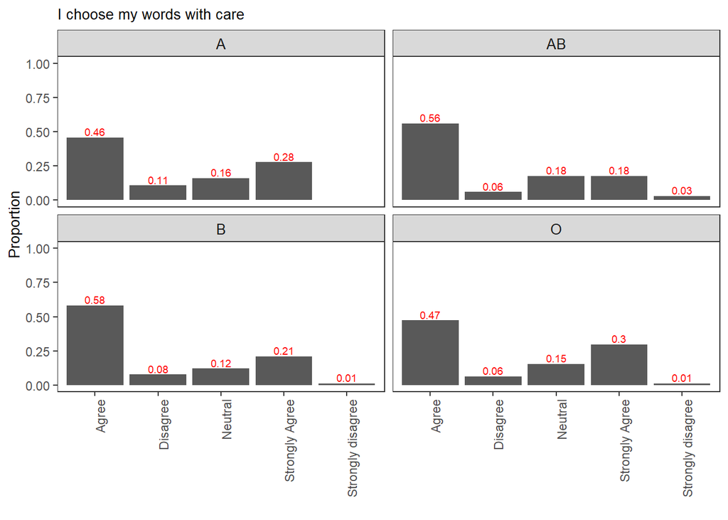

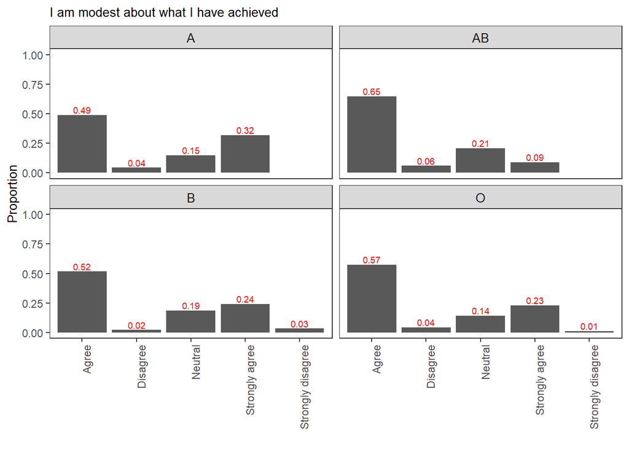

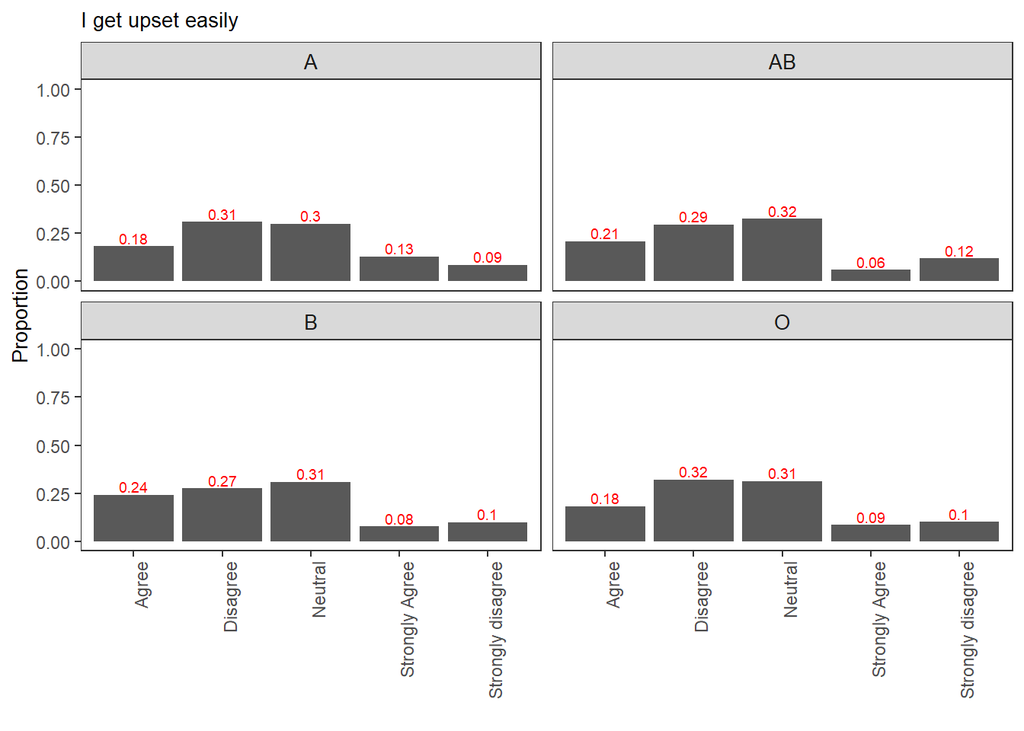

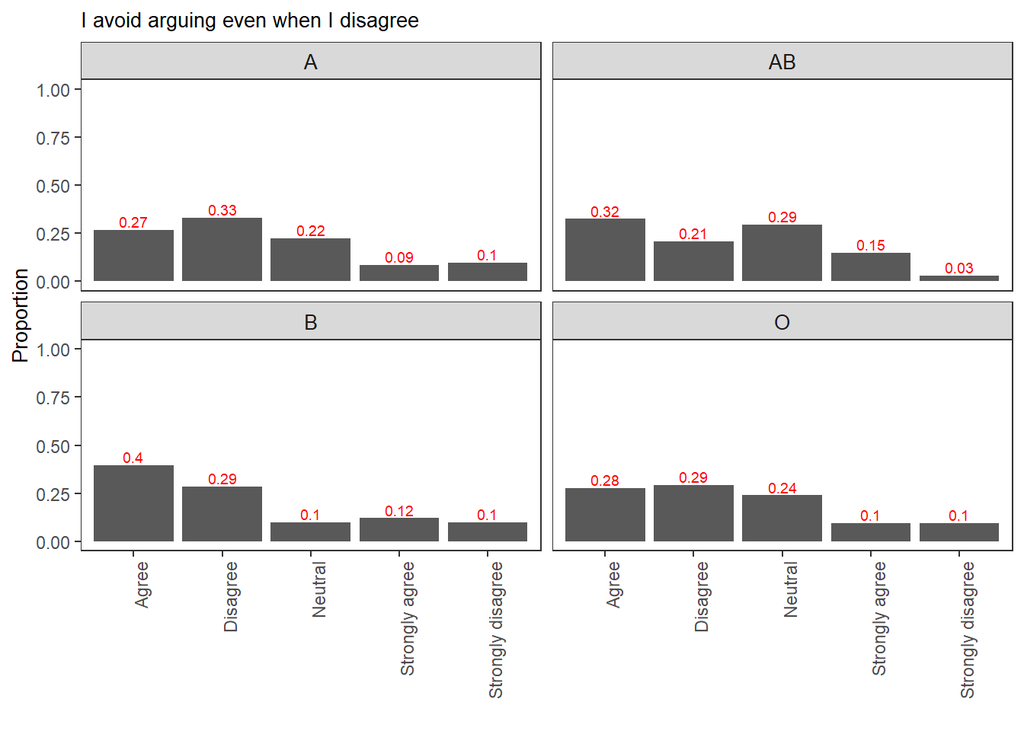

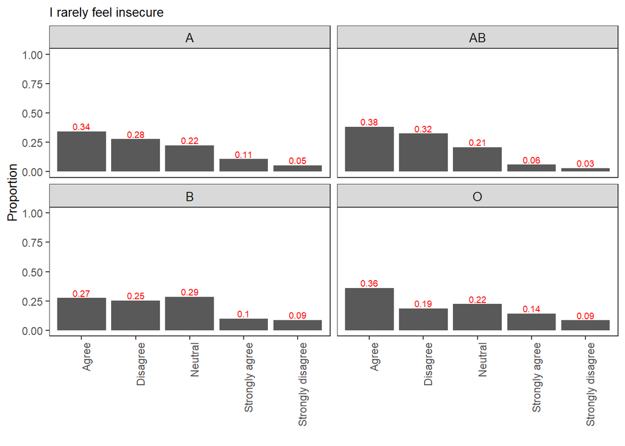

- NEXT STEPS:
  - Name groups
  - Interpret plots … At a quick glance, AB people seem to stand out in many aspects
  - Find a way to make document shorter. Maybe make each group name clickable and plots are reveal upon clicling on links
  - Contibue analysis with psychometric traits that stand out: add Rh Factor
  - Impact of age
  - Impact of countries of residence vs. origin (focus on 3 main countries)